# COVIDMINDER Incident and Mortality Notebook

Michél McFadden

5/4/2020

##### **Why Incident and Mortality Is Important :**

Looking at Incident and Mortality is important because it can help predict the future of the state. To flatten the curve states want to keep their incident rates low over time. It may be possible to predict when states might open by looking at their incident rates and mortality rates. It’s reasonable to assume that states that have low rates for both will open back up sooner than states with higher rates.

#### **ABOUT THE VISUALIZATIONS:**

These maps go to show the different rates for states. The Mortality Rate graph uses the data untouched directly from the CSV and the Incident Graph takes the log(X) of each states incident rate (the amount of people that catch coronvirus divided by the population value.

#### **What does the mortality rate look like across the United States?**

*This plot shows the different mortality rates across the US. This data is from JHU’s Github repo.*

[interactive chart not shown]

#### **What does the incident rate look like across the United States?**

*This plot shows the different incident rates across the US. ‘Incident rate’ is defined as the amount of people who catch coronavirus in a given state divided by the population of that state. This data is from JHU’s Github repo.*

[interactive chart not shown]

*New York had such inflated values that including them in the analysis would lead to overfitting the data. New York data was removed from the analysis techniques below*

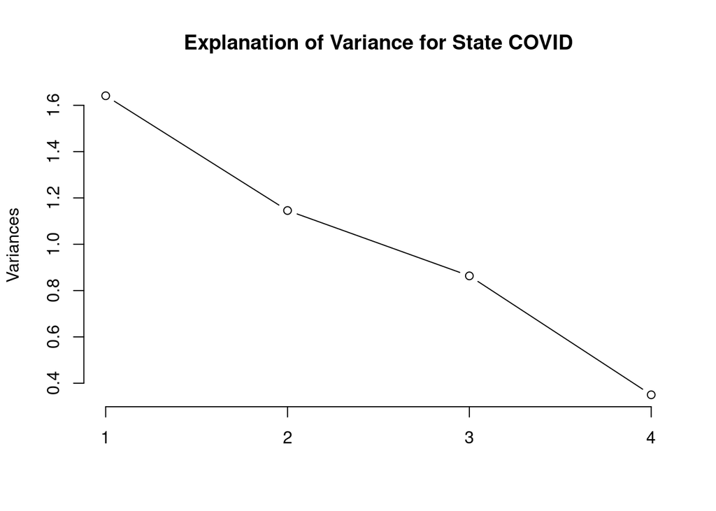

# A look at the heatmap values for the different cluster of states.

- Cluster A is characterized by it’s low testing, incident, and mortality rates and medium hospitalization rate.
- Cluster B is characterized by it’s low hospitalization rate, medium testing and mortality rates, and high incident rate.
- Cluster C is characterized by it’s low rates for all 4 features.

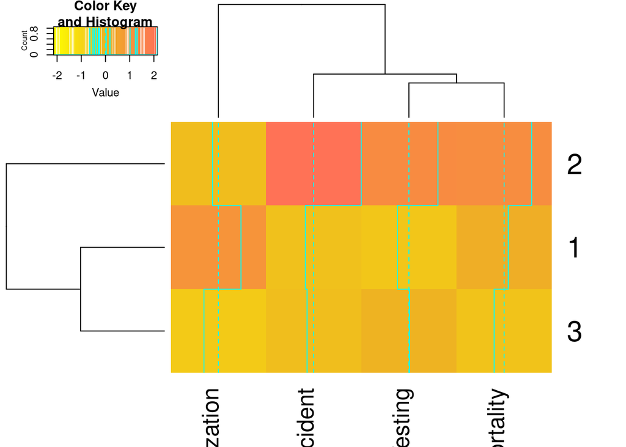

# What information can we get from looking at a biplot?

#### **A biplot shows the characteristics of a cluster in relation to one another**

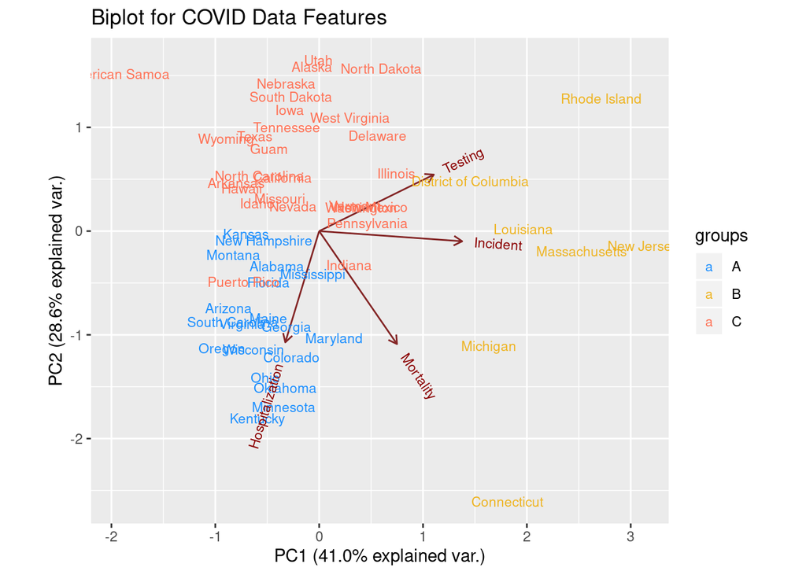